# TD

```python
#Importing libraries needed throughout
import numpy as np
import pandas as pd
import matplotlib.pyplot as plt
import scipy.stats as stats
import seaborn as sns
%matplotlib inline
%pylab inline
```

==========

Hello reader!

Within this notebook, I will be exploring the Titanic Passenger data available through Kaggle via Udacity. The Kaggle website is the primary host for the CSV data and also features a brief description of the variables used.

https://www.kaggle.com/c/titanic

My data was downloaded 05/21/2016 and does not reflect any changes that have occurred to the data after that date.

This notebook was created as part of a Data Analysis capstone project to be presented to a Udacity reviewer for criticism.

The investigation and analysis of the dataset provided is broken into the following phases:

1. Data Exploration and Wrangling
2. 1-Dimensional Visualization and Analysis
3. 2-Dimensional Visualization and Analysis

Throughout the project, I refer to Survived as the dependent variable and all others as independent variables. The assumption of taking Survived for granted as the dependent variable is justifiable primarily due to chronology. Influence may only be assumed to be one-directional, eg Pclass may alter Survived, but Survived couldn't have altered Pclass. Arguments may be made regarding correlation between independent variables (ex. Pclass and Fare), but I don't analyze these relationships in this notebook.

Thank you for reading!

==========

Phase 1: Data Exploration and Wrangling

Within this phase, I follow these steps:

1. Read the CSV into a pandas DataFrame
2. Split similar data into separate DataFrames for description using the .apply() method with functions I have defined.

```python
#Reading CSV into pandas dataframe and taking a quick look at the data's format
titanic = pd.read_csv("titanic_data.csv")
titanic.head()
```

|  | PassengerId | Survived | Pclass | Name | Sex | Age | SibSp | Parch | Ticket | Fare | Cabin | Embarked |
| --- | --- | --- | --- | --- | --- | --- | --- | --- | --- | --- | --- | --- |
| 0 | 1 | 0 | 3 | Braund, Mr. Owen Harris | male | 22.0 | 1 | 0 | A/5 21171 | 7.2500 | NaN | S |
| 1 | 2 | 1 | 1 | Cumings, Mrs. John Bradley (Florence Briggs Th... | female | 38.0 | 1 | 0 | PC 17599 | 71.2833 | C85 | C |
| 2 | 3 | 1 | 3 | Heikkinen, Miss. Laina | female | 26.0 | 0 | 0 | STON/O2. 3101282 | 7.9250 | NaN | S |
| 3 | 4 | 1 | 1 | Futrelle, Mrs. Jacques Heath (Lily May Peel) | female | 35.0 | 1 | 0 | 113803 | 53.1000 | C123 | S |
| 4 | 5 | 0 | 3 | Allen, Mr. William Henry | male | 35.0 | 0 | 0 | 373450 | 8.0500 | NaN | S |

At this point, I observe that the data includes an ID key for each passenger as well as continuous and categorical data for each ID.

Because PassengerId acts as our index and further string-type identifiers will be superfluous for exploration and analysis, I drop the column 'Name', 'Ticket', and 'Cabin.' Dropping in-place will allows continued use of our original DataFrame.

```python
titanic.drop(['Name','Ticket','Cabin'],axis=1,inplace=True)
```

Next, I describe our categorical and continuous variables separately and in aggregate. I create two new variables to refer to continuous and categorical data within our titanic DataFrame.

```python
titanic_cat = titanic.drop(['Age','Fare','PassengerId'],axis=1,inplace=False)
titanic_cont = titanic.drop(['Survived','Pclass','Sex','SibSp','Parch','Embarked','PassengerId'],axis=1,inplace=False)

print titanic_cat.head()
print titanic_cont.head()
```

```
   Survived  Pclass     Sex  SibSp  Parch Embarked
0         0       3    male      1      0        S
1         1       1  female      1      0        C
2         1       3  female      0      0        S
3         1       1  female      1      0        S
4         0       3    male      0      0        S
    Age     Fare
0  22.0   7.2500
1  38.0  71.2833
2  26.0   7.9250
3  35.0  53.1000
4  35.0   8.0500
```

Defining description functions and applying them to our reference variables will be our next step.

```python
def describe_1D_num_data(data):
    print '===== Describing: ' + str(data.name) + ' ====='
    print 'Mean:', np.mean(data)
    print 'Standard deviation:', np.std(data)
    print 'Minimum:', np.min(data)
    print 'Maximum:', np.max(data)
    print 'Data Integrity:', len(data) - data.count(), 'out of', len(data),'are NaN or null'

def describe_1D_cat_data(data):
    print '===== Describing: ' + str(data.name) + ' ====='
    print data.value_counts()
    print 'Data Integrity:', len(data) - data.count(), 'out of', len(data),'are NaN or null'

print titanic_cont.apply(describe_1D_num_data)
print titanic_cat.apply(describe_1D_cat_data)
```

```
===== Describing: Age =====
Mean: 29.6991176471
Standard deviation: 14.5163211508
Minimum: 0.42
Maximum: 80.0
Data Integrity: 177 out of 891 are NaN or null
===== Describing: Fare =====
Mean: 32.2042079686
Standard deviation: 49.6655344448
Minimum: 0.0
Maximum: 512.3292
Data Integrity: 0 out of 891 are NaN or null
Age     None
Fare    None
dtype: object
===== Describing: Survived =====
0    549
1    342
Name: Survived, dtype: int64
Data Integrity: 0 out of 891 are NaN or null
===== Describing: Pclass =====
3    491
1    216
2    184
Name: Pclass, dtype: int64
Data Integrity: 0 out of 891 are NaN or null
===== Describing: Sex =====
male      577
female    314
Name: Sex, dtype: int64
Data Integrity: 0 out of 891 are NaN or null
===== Describing: SibSp =====
0    608
1    209
2     28
4     18
3     16
8      7
5      5
Name: SibSp, dtype: int64
```

[output cut: 9 more lines]

```
Name: Parch, dtype: int64
Data Integrity: 0 out of 891 are NaN or null
===== Describing: Embarked =====
S    644
C    168
Q     77
Name: Embarked, dtype: int64
Data Integrity: 2 out of 891 are NaN or null
Survived    None
Pclass      None
Sex         None
SibSp       None
Parch       None
Embarked    None
dtype: object
```

=====

Phase 2: 1-Dimensional Visualization and Analysis

In this phase, I create histograms to observe our data's frequency across categories or through the range of its continuity.

Due to the seeming exponential shape of the Fare variable, I choose add a transformed version of Fare to our full dataset (FareLoge). By taking the natural log of the Fare data, I prepare for later 2-dimensional analysis that benefits from the assumption of linear data.

While transforming the Fare data, I discover a subset of passengers that pay 0.0 Fare. I decide to create a new boolean Series within the DataFrame, NonPay, to reflect this group in order to replace these zeros with NaNs - this corrects the 1-dimesional data for Fare, which was being skewed by the zeros. More on this subgroup later.

We'll begin with our continuous variables - Age & Fare.

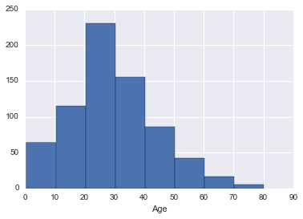

```python
# np.isnan avoids the NaNs present in the Age array
hist(titanic_cont.Age[~np.isnan(titanic_cont.Age)],bins=8)
plt.xlabel('Age')
```

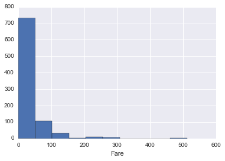

```python
# Here I see that there seems to be an extreme tail for Fare price that may
# represent an exponential distribution rather than a linear one.
hist(titanic_cont.Fare)
plt.xlabel('Fare')
```

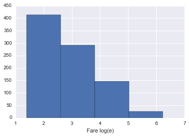

```python
# Let's observe the log(e) of Fare to put it into a linear context. We'll add
# a log(e) version of Fare later for 2-D comparison with other linear factors.
# the np.isnan and np.isinf is called to deal with NaNs/infinities caused by zeroes in Fare,
# which we will re-categorize later.

fare_loge = np.log(titanic.Fare)
fare_loge = fare_loge.rename("FareLoge")
hist(fare_loge[~np.isnan(fare_loge)&~np.isinf(fare_loge)],bins=4)
plt.xlabel('Fare log(e)')
```

Next, we will create histograms for our categorical variables, starting with the most consequential - Survived.

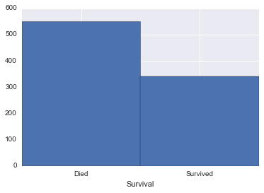

```python
# Our dearly departed dependent variable
plt.xticks([0.25,0.75],('Died','Survived'))
hist([0,1],weights=titanic_cat.Survived.value_counts().values,bins=2)
plt.xlabel('Survival')
```

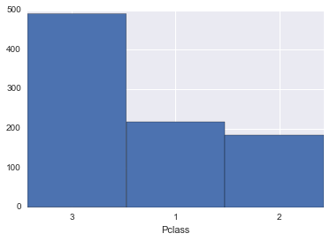

```python
plt.xticks([0.3,1,1.7],(3,1,2))
plt.xlabel('Pclass')
hist([0,1,2],weights=titanic_cat.Pclass.value_counts(),bins=3)
```

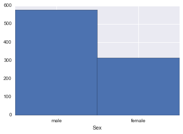

```python
plt.xticks([0.25,0.75],('male','female'))
hist([0,1],weights=titanic_cat.Sex.value_counts().values,bins=2)
plt.xlabel('Sex')
```

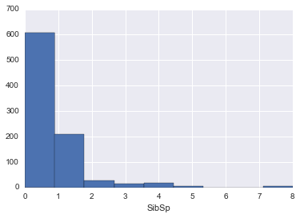

```python
hist(titanic_cat.SibSp,bins=9)
plt.xlabel('SibSp')
```

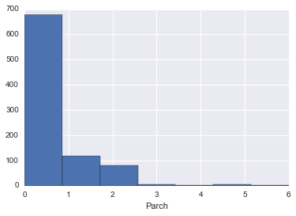

```python
hist(titanic_cat.Parch,bins=7)
plt.xlabel('Parch')
```

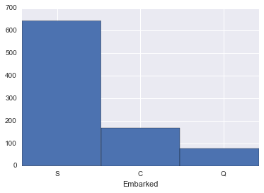

```python
plt.xticks([0.3,1,1.7],('S','C','Q'))
hist([0,1,2],weights=titanic_cat.Embarked.value_counts().values,bins=3)
plt.xlabel('Embarked')
```

Now equipped with the shapes of our variables, it's time to peer more deeply into our subgroup of non-paying passengers. There are only 15 non-paying passengers, but they are highly correlated.

```python
# Interesting that the minimum fare was 0.0, kind of curious about that/those
# passenger(s). They may be problem data, eg NaN rather than actually zero payers.
# They may also be messing up our Fare 1-D data description. Let's list them.

non_paying = titanic[titanic.Fare==0.0]
print len(non_paying)
non_paying
```

```
15
```

|  | PassengerId | Survived | Pclass | Sex | Age | SibSp | Parch | Fare | Embarked |
| --- | --- | --- | --- | --- | --- | --- | --- | --- | --- |
| 179 | 180 | 0 | 3 | male | 36.0 | 0 | 0 | 0.0 | S |
| 263 | 264 | 0 | 1 | male | 40.0 | 0 | 0 | 0.0 | S |
| 271 | 272 | 1 | 3 | male | 25.0 | 0 | 0 | 0.0 | S |
| 277 | 278 | 0 | 2 | male | NaN | 0 | 0 | 0.0 | S |
| 302 | 303 | 0 | 3 | male | 19.0 | 0 | 0 | 0.0 | S |
| 413 | 414 | 0 | 2 | male | NaN | 0 | 0 | 0.0 | S |
| 466 | 467 | 0 | 2 | male | NaN | 0 | 0 | 0.0 | S |
| 481 | 482 | 0 | 2 | male | NaN | 0 | 0 | 0.0 | S |
| 597 | 598 | 0 | 3 | male | 49.0 | 0 | 0 | 0.0 | S |
| 633 | 634 | 0 | 1 | male | NaN | 0 | 0 | 0.0 | S |
| 674 | 675 | 0 | 2 | male | NaN | 0 | 0 | 0.0 | S |
| 732 | 733 | 0 | 2 | male | NaN | 0 | 0 | 0.0 | S |
| 806 | 807 | 0 | 1 | male | 39.0 | 0 | 0 | 0.0 | S |
| 815 | 816 | 0 | 1 | male | NaN | 0 | 0 | 0.0 | S |
| 822 | 823 | 0 | 1 | male | 38.0 | 0 | 0 | 0.0 | S |

From this list, we may observe the following:

- Non-payers have a very poor survival rate (1/15)
- Non-payers are from various Pclass
- Non-payers are all male
- Non-payers tend to be older but are largely missing Age data
- Non-payers have no parents, children, siblings, or spouses aboard.
- Non-payers all embarked in Southampton (S)

From these bits of evidence, I infer that these passengers are crew members. I decide to create a new boolean Series to represent them, NonPay, and convert their Fare values to NaNs.

This decision is, ultimately, subjective to the question being asked about the Fare data. If the question being asked is -

What is the mean price paid to board the Titanic?

We wouldn't need to transform the data. However, I think the more reasonable and informative question is -

What is the Titanic's mean fare price?

In this case, we need to exclude those from consideration that did not pay a fare.

```python
non_pay = pd.Series(data=(titanic.Fare==0.0),dtype=bool)
non_pay = non_pay.rename("NonPay")
non_pay
titanic = pd.concat([titanic,non_pay],axis=1)

replace_NaN = non_pay.replace(to_replace=False, value=titanic.Fare)
replace_NaN = replace_NaN.replace(to_replace=True, value=NaN)
new_fare = replace_NaN.rename("Fare")

titanic.drop("Fare",axis=1,inplace=True)
titanic = pd.concat([titanic,new_fare],axis=1)
titanic.head()
```

|  | PassengerId | Survived | Pclass | Sex | Age | SibSp | Parch | Embarked | NonPay | Fare |
| --- | --- | --- | --- | --- | --- | --- | --- | --- | --- | --- |
| 0 | 1 | 0 | 3 | male | 22.0 | 1 | 0 | S | False | 7.2500 |
| 1 | 2 | 1 | 1 | female | 38.0 | 1 | 0 | C | False | 71.2833 |
| 2 | 3 | 1 | 3 | female | 26.0 | 0 | 0 | S | False | 7.9250 |
| 3 | 4 | 1 | 1 | female | 35.0 | 1 | 0 | S | False | 53.1000 |
| 4 | 5 | 0 | 3 | male | 35.0 | 0 | 0 | S | False | 8.0500 |

Now that zero Fares have been converted to NaNs, we can create a new Series for our DataFrame representing the natural log of Fare.

```python
fare_loge = np.log(titanic.Fare)
fare_loge = fare_loge.rename("FareLoge")
titanic = pd.concat([titanic,fare_loge],axis=1)
titanic.head()
```

|  | PassengerId | Survived | Pclass | Sex | Age | SibSp | Parch | Embarked | NonPay | Fare | FareLoge |
| --- | --- | --- | --- | --- | --- | --- | --- | --- | --- | --- | --- |
| 0 | 1 | 0 | 3 | male | 22.0 | 1 | 0 | S | False | 7.2500 | 1.981001 |
| 1 | 2 | 1 | 1 | female | 38.0 | 1 | 0 | C | False | 71.2833 | 4.266662 |
| 2 | 3 | 1 | 3 | female | 26.0 | 0 | 0 | S | False | 7.9250 | 2.070022 |
| 3 | 4 | 1 | 1 | female | 35.0 | 1 | 0 | S | False | 53.1000 | 3.972177 |
| 4 | 5 | 0 | 3 | male | 35.0 | 0 | 0 | S | False | 8.0500 | 2.085672 |

=====

Phase 3: 2-Dimensional Visualization and Analysis

This final phase will deal with relationships between Survived, our assumed dependent variable, and other salient independent variables. We identify correlation coefficients using Pearson's R via the handy .corr() method.

I choose to drop the Embarked variable, as it would have required paired dummy variables to analyze. In our Pearson's R table, we can also observe that FareLoge and Pclass are indeed highly correlated, but this won't be further analyzed. You don't need p-values to tell you that 1st-class tickets cost more.

First, we need to replace the values in Sex, which are strings, with dummy variables. We will use the convention that Female = True = 1.

```python
bool_sex = pd.Series(data=(titanic.Sex=="female"),dtype=bool)
titanic.drop('Sex',axis=1,inplace=True)
titanic = pd.concat([titanic,bool_sex],axis=1)
titanic.drop('Embarked',axis=1,inplace=True)
titanic.head()
```

|  | PassengerId | Survived | Pclass | Age | SibSp | Parch | NonPay | Fare | FareLoge | Sex |
| --- | --- | --- | --- | --- | --- | --- | --- | --- | --- | --- |
| 0 | 1 | 0 | 3 | 22.0 | 1 | 0 | False | 7.2500 | 1.981001 | False |
| 1 | 2 | 1 | 1 | 38.0 | 1 | 0 | False | 71.2833 | 4.266662 | True |
| 2 | 3 | 1 | 3 | 26.0 | 0 | 0 | False | 7.9250 | 2.070022 | True |
| 3 | 4 | 1 | 1 | 35.0 | 1 | 0 | False | 53.1000 | 3.972177 | True |
| 4 | 5 | 0 | 3 | 35.0 | 0 | 0 | False | 8.0500 | 2.085672 | False |

```python
# Time for the good stuff. Let's see Pearson's R across these variables.
titanic.corr()
```

|  | PassengerId | Survived | Pclass | Age | SibSp | Parch | NonPay | Fare | FareLoge | Sex |
| --- | --- | --- | --- | --- | --- | --- | --- | --- | --- | --- |
| PassengerId | 1.000000 | -0.005007 | -0.035144 | 0.036847 | -0.057527 | -0.001652 | 0.035816 | 0.015861 | 0.007134 | -0.042939 |
| Survived | -0.005007 | 1.000000 | -0.338481 | -0.077221 | -0.035322 | 0.081629 | -0.085343 | 0.252453 | 0.325452 | 0.543351 |
| Pclass | -0.035144 | -0.338481 | 1.000000 | -0.369226 | 0.083081 | 0.018443 | -0.058774 | -0.561517 | -0.754893 | -0.131900 |
| Age | 0.036847 | -0.077221 | -0.369226 | 1.000000 | -0.308247 | -0.189119 | 0.037315 | 0.098981 | 0.135352 | -0.093254 |
| SibSp | -0.057527 | -0.035322 | 0.083081 | -0.308247 | 1.000000 | 0.414838 | -0.062097 | 0.155240 | 0.324373 | 0.114631 |
| Parch | -0.001652 | 0.081629 | 0.018443 | -0.189119 | 0.414838 | 1.000000 | -0.061983 | 0.212137 | 0.339180 | 0.245489 |
| NonPay | 0.035816 | -0.085343 | -0.058774 | 0.037315 | -0.062097 | -0.061983 | 1.000000 | NaN | NaN | -0.096532 |
| Fare | 0.015861 | 0.252453 | -0.561517 | 0.098981 | 0.155240 | 0.212137 | NaN | 1.000000 | 0.817386 | 0.175592 |
| FareLoge | 0.007134 | 0.325452 | -0.754893 | 0.135352 | 0.324373 | 0.339180 | NaN | 0.817386 | 1.000000 | 0.247711 |
| Sex | -0.042939 | 0.543351 | -0.131900 | -0.093254 | 0.114631 | 0.245489 | -0.096532 | 0.175592 | 0.247711 | 1.000000 |

Determining whether the relationship between Sex and Survived is statistically significant requires the use of a chi-squared test. The chi-squared test compares observed frequencies within categories against their expected frequencies given no relationship.

In this case, our expected frequency isn't perfectly equal - there are more men aboard the Titanic than women, so we need to calculate the ratio of men to women in order to calculate the expected frequency of survivors.

Because this is our first true statistical test, it may be helpful to be reminded of the limitations of the test. Our chi-squared test will reveal solely whether the relationship revealed by our Pearson's R correlation coefficient is statistically significant. In order to further analyze the extent of the independent variable's influence, we would need to use ANOVA and regression.

For our finding to be rigorous, it must be assumed that the sample data are truly random and representative of the full population of the Titanic. Only then may we assume that the relationship we observe in our sample group may also be applied to the population.

Test parameters as follows:

h0: There is no relationship between Sex and Survived.

h1: Women survive at a higher rate than men.

p = .01

```python
titanic_testvars = pd.concat([titanic.Survived,titanic.Sex],axis=1)
group_sex = titanic_testvars.groupby(by='Sex')
sex_sum = group_sex.Survived.sum()
print sex_sum.values

total_women = titanic.Sex.sum()
total_people = len(titanic.Sex)
total_men = total_people - total_women

male_ratio = float(total_men) / total_people # float added to enable float division
female_ratio = 1 - male_ratio
total_survived = titanic.Survived.sum()

expected_obs = [male_ratio*total_survived,female_ratio*total_survived]
print expected_obs

sex_chisq = stats.chisquare(f_obs=sex_sum.values, f_exp=expected_obs)
sex_chisq
```

```
[109 233]
[221.4747474747475, 120.52525252525251]
```

```
Power_divergenceResult(statistic=162.08166685161618, pvalue=3.9705163896586144e-37)
```

Our program's result returns an extremely low p-value, much less than .01. Therefore, we may reject the null hypothesis and conclude that women survived at a higher rate than men.

Ultimately, this isn't too surprising. I printed the observed and expected values above the test statistic - the values are virtually opposite. Women, composing around 1/3 of the ship population, represent close to 2/3 of the survivors.

Finally, we will investigate the relationship between FareLoge and Survived. First, we will create a visualization of the difference between the probability density functions of survivors and non-survivors vis a vis their fare price.

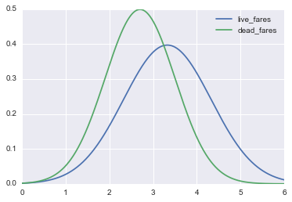

```python
titanic_testvars = pd.concat([titanic.Survived,titanic.FareLoge],axis=1)
group_survive = titanic_testvars.groupby(by='Survived')
dead_fares = group_survive.get_group(0)
live_fares = group_survive.get_group(1)

x = np.linspace(0,6,1000)
y1 = stats.norm.pdf(x, loc=live_fares.FareLoge.mean(), scale=live_fares.FareLoge.std(ddof=0))
y2 = stats.norm.pdf(x, loc=dead_fares.FareLoge.mean(), scale=dead_fares.FareLoge.std(ddof=0))
plt.plot(x,y1, label='live_fares')
plt.plot(x,y2, label='dead_fares')
plt.legend()
plt.show()
```

There seems to be a definite difference between the survivors and non-survivors, though there is also quite a bit of overlap. Given that our independent variable is actually the natural log of Fare, this isn't too surprising.

We will now conduct our Student's t-test, a test for statistical significance between categorical and continuous variables. The test determines whether samples within different categories show enough differentiation to be more than random.

Test parameters are as follows:

h0: There is no relationship between FareLoge and Survived.

h1: The mean FareLoge for survivors is higher than for non-survivors.

p = .01

```python
stats.ttest_ind(live_fares.FareLoge,dead_fares.FareLoge,equal_var=False,nan_policy='omit')
```

```
Ttest_indResult(statistic=9.6795150859232102, pvalue=1.0557027132781137e-20)
```

Our Student's t-test returns a p-value below .01. Therefore, we may reject the null hypothesis and conclude that FareLoge positively correlates with Survived.

=====

Conclusions

Through our tests, we have concluded that categorization as a survivor of the Titanic disaster is positively correlated with female gender and fare price via its natural log.

Many further avenues for study exist. Gender and FareLoge may be more deeply investigated using ANOVA, as well as interaction effects that may occur between independent variables.